# Ankieta

Olaf Werner

November 11, 2018

## Ankieta

Moim zadaniem było przeprowadzić badania nad tym który rodzaj wykresu jest lepszy: słupkowy czy kołowy. By to zrobić wziąłem zbiór danych który miałem pod ręką, przekształciłem go i przedstawiłem za pomocą dwóch wykresów: słupkowego i kołowego. Następnie ułożyłem do tych wykresów pytania. Później przeprowadziłem ankietę w szkole podstawowej. W tej ankiecie dzieci otrzymywały jeden z wykresów i na podstawie jego musiały odpowiadać na ułożone wcześniej pytania. Odpowiedzi udzieliło 22 uczniów w wieku 8 lat.

## Wykres Słupkowy

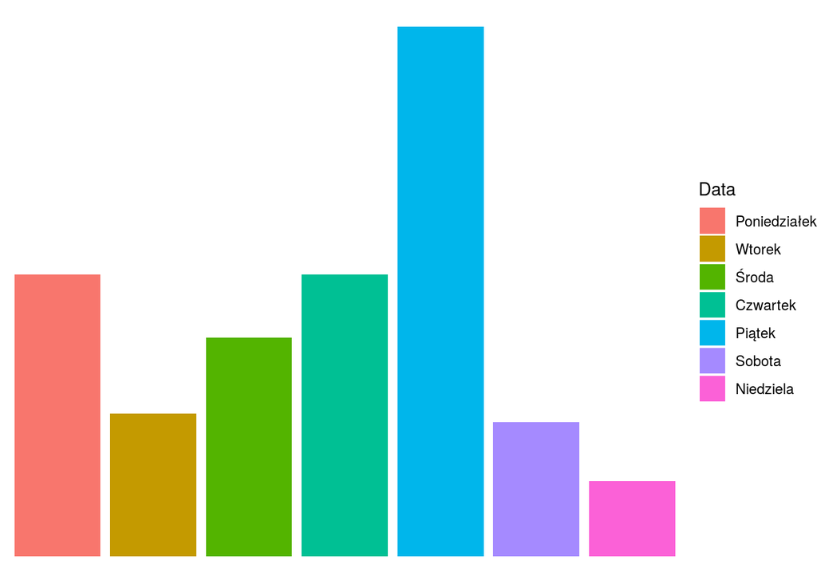

## Wykres Kołowy

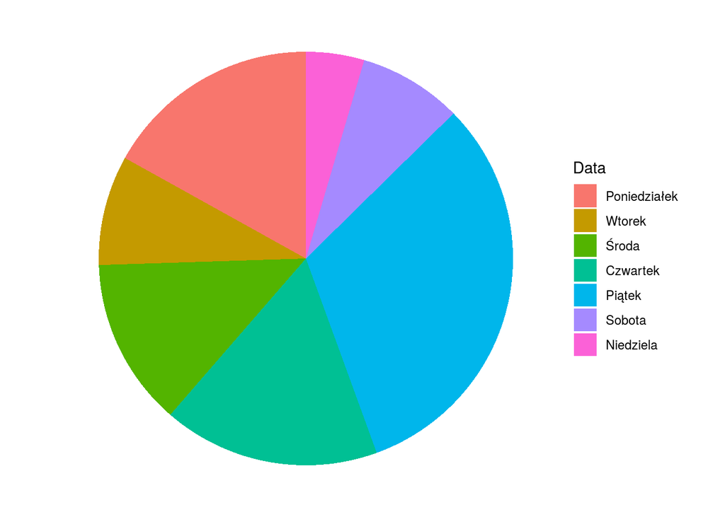

## Pytania:

1. Który dzień tygodnia jest największy?
2. Czy suma środy i poniedziałku jest większa od piątku?
3. Co jest większe: poniedziałek czy czwartek?
4. Czy suma środy i niedzieli jest większa od poniedziałku?
5. Czy sobota jest co najmniej 2 razy większa od niedzieli?
6. Czy środa jest co najmniej 4 razy większa od niedzieli?
7. Co jest większe: sobota czy wtorek?
8. Co jest większe: suma wtorku i środy czy suma poniedzialku i niedzieli?
9. Czy wygodnie pracowało się z wykresem?

## Odpowiedzi:

1. Piątek
2. Nie
3. Takie same
4. Tak minimalnie(70 do 67)
5. Nie
6. Nie
7. Wtorek minimalnie(34 do 32)
8. Wtorek i środa minimalnie(86 do 85)
9. odpowiedź ucznia

## Pytanie 1 dobra odpowiedź: Piątek

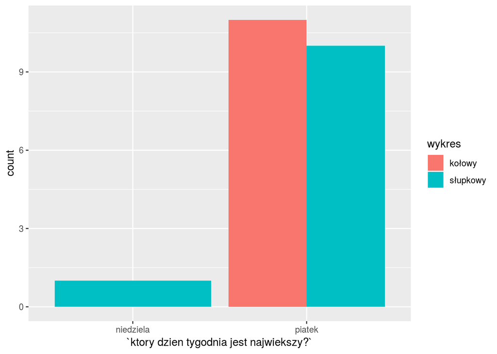

## Pytanie 2 dobra odpowiedź: Nie

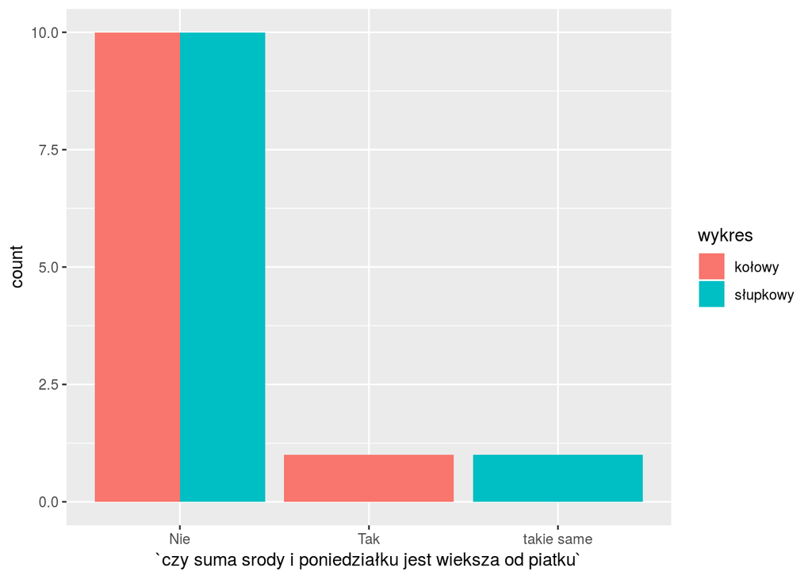

## Pytanie 3 dobra odpowiedź: takie same

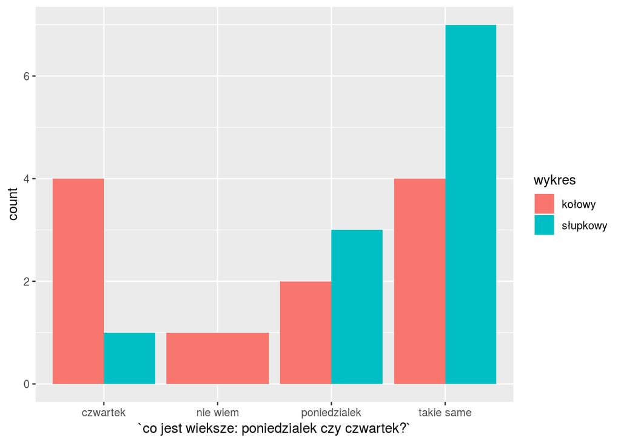

## Pytanie 4 dobra odpowiedź: Tak minimalnie(70 do 67)

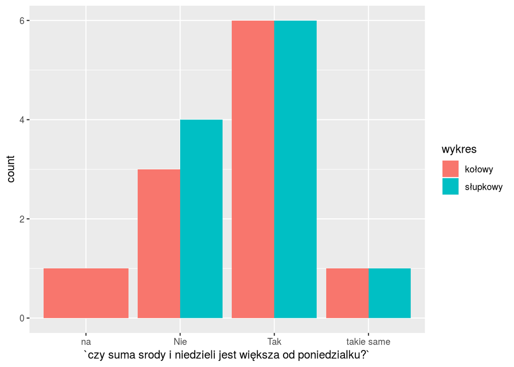

## Pytanie 5 dobra odpowiedź: Nie

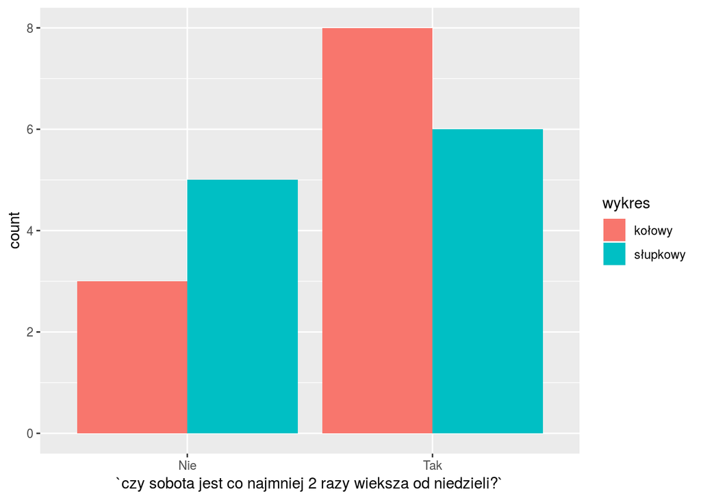

## Pytanie 6 dobra odpowiedź: Nie

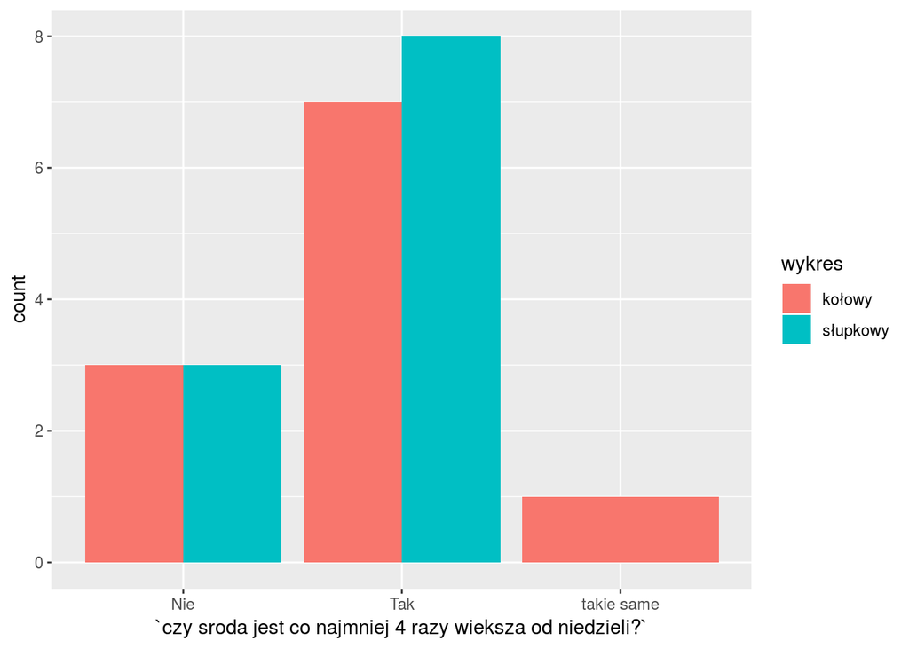

## Pytanie 7 dobra odpowiedź: Wtorek minimalnie(34 do 32)

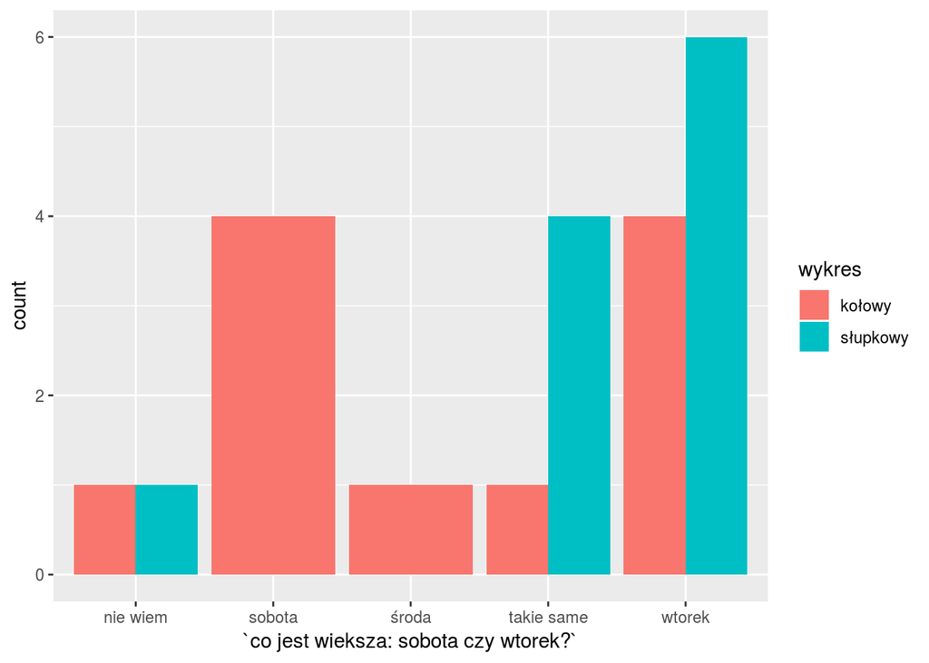

## Pytanie 8 dobra odpowiedź: Wtorek i środa minimalnie(86 do 85)

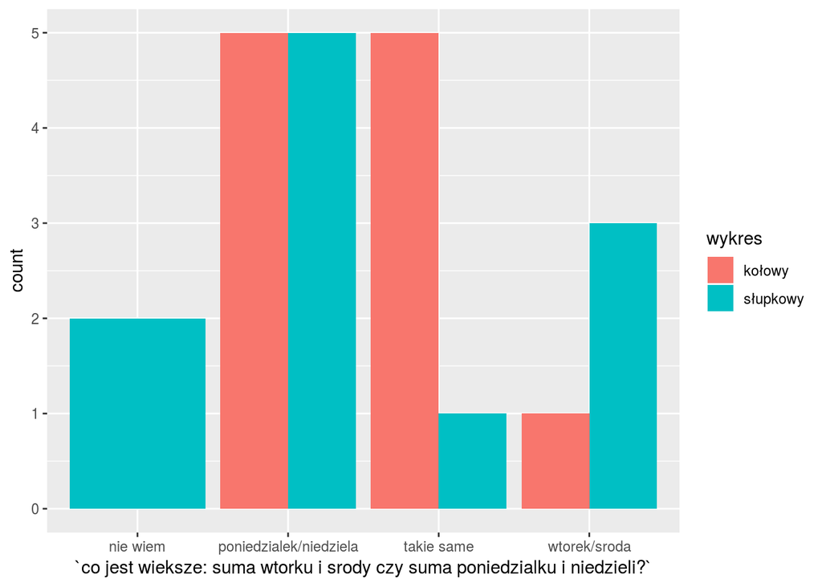

## Pytanie 9

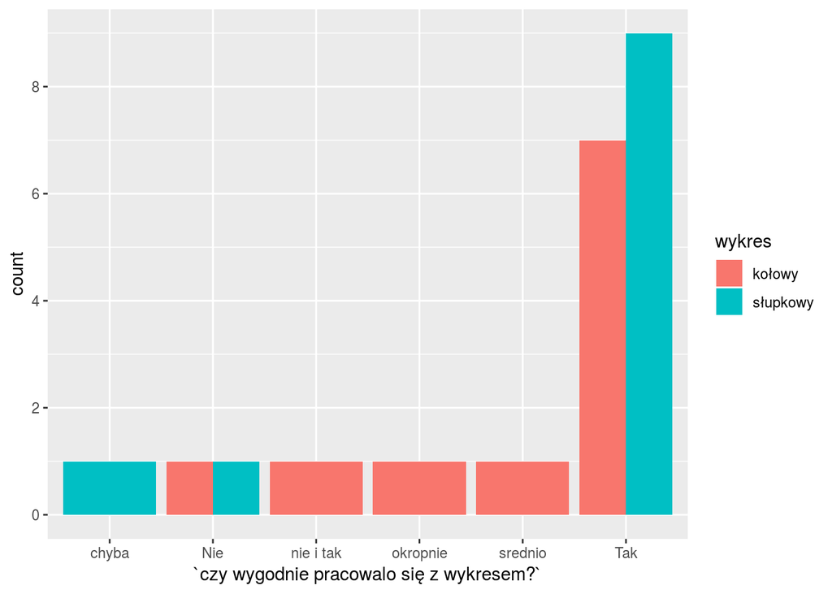

## Podsumowanie:

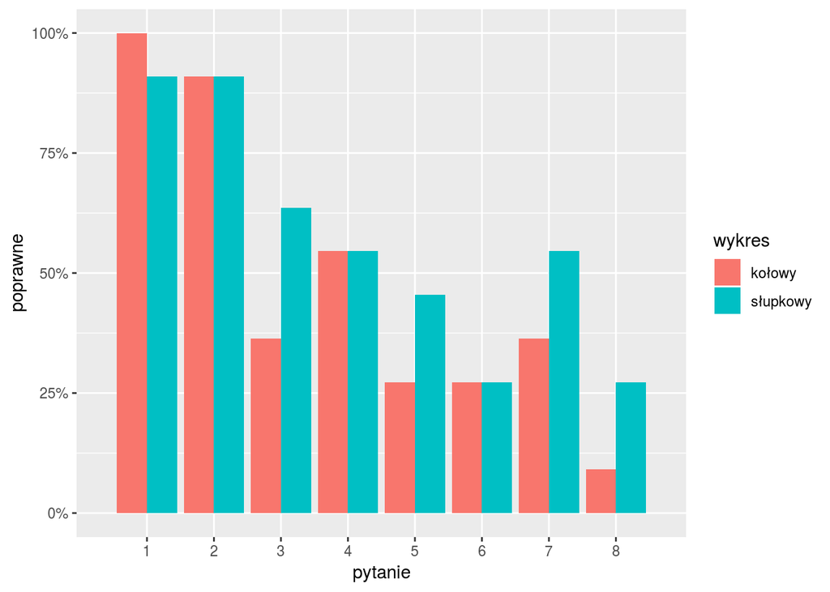

| wykres | pytanie1 | pytanie2 | pytanie3 | pytanie4 | pytanie5 | pytanie6 | pytanie7 | pytanie8 |
| --- | --- | --- | --- | --- | --- | --- | --- | --- |
| kołowy | 100 % | 91 % | 36 % | 55 % | 27 % | 27 % | 36 % | 9 % |
| słupkowy | 91 % | 91 % | 64 % | 55 % | 45 % | 27 % | 55 % | 27 % |

Jak widzimy wykresy słupkowe są na ogół lepsze niż wykresy kołowe. Inna rzeczą która nie została dokładnie zmierzona jest czas pracy z danym wykresem, jednakże dzieci wykonujące zadanie za pomocą wykresu słupkowego kończyły prace w znacznie krótszym czasie niż te posługujące się wykresem kołowym. Poza tym wykres kołowy zebrał więcej negatywnych opinii.